# Democracies and GDP’s Around The World-An Analysis

Liav Botton & Shachar Cygler, At the guidence of prof. Or Tzuk

20/04/2025

# Introduction

Democracy has changed a lot since the days of the Greek empire, where small group- males with property and honor, had a privilege to vote about issues concerning everyday life, and now days, Democracy has lots of aspects and ways to implement it.  
Democracy Index try to do the hard mission of grading each country and its level of Democracy.  
Besides being the preferred way to live in the Western civilization, democracy believed to be a more prosperous and economically rewarding to the civilians living under this such of authorities. A way to examine this assumption is by checking the Growth Domestic Production (GDP) of each country and look at the data.

# 1 **Data prep and Democracy Index**

## (a) Loading the data via URL connection:

```r
democracy <- read_html("https://en.wikipedia.org/wiki/Democracy_Index")
all.tables = html_nodes(democracy, "table")
regions <- as.data.frame(html_table(all.tables[4], fill = TRUE))
countries <- as.data.frame(html_table(all.tables[6], fill = TRUE))
components <- as.data.frame(html_table(all.tables[7], fill = TRUE)) %>% filter(Country != c("Full democracies",NA)) %>% select(- c(".mw.parser.output..tooltip.dotted.border.bottom.1px.dotted.cursor.help.Δ.Rank"))
head(regions,5)
```

```
##                            Region Coun.tries X2024 X2023 X2022 X2021 X2020
## 1                  Western Europe         21  8.38  8.37  8.36  8.23  8.29
## 2                   North America          2  8.27  8.27  8.37  8.36  8.58
## 3 Latin America and the Caribbean         24  5.61  5.68  5.79  5.83  6.09
## 4 Eastern Europe and Central Asia         28  5.35  5.37  5.39  5.36  5.36
## 5            Asia and Australasia         28  5.31  5.41  5.46  5.62  5.67
##   X2019 X2018 X2017 X2016 X2015 X2014 X2013 X2012 X2011 X2010 X2008 X2006
## 1  8.35  8.35  8.38  8.40  8.42  8.41  8.41  8.44  8.40  8.45  8.61  8.60
## 2  8.59  8.56  8.56  8.56  8.56  8.59  8.59  8.59  8.59  8.63  8.64  8.64
## 3  6.13  6.24  6.26  6.33  6.37  6.36  6.38  6.36  6.35  6.37  6.43  6.37
## 4  5.42  5.42  5.40  5.43  5.55  5.58  5.53  5.51  5.50  5.55  5.67  5.76
## 5  5.67  5.67  5.63  5.74  5.74  5.70  5.61  5.56  5.51  5.53  5.58  5.44
```

```r
head(countries,5)
```

```
##                  Region X2024.rank     Country    Regime.type X2024 X2023 X2022
## 1 Asia and Australasia        167 Afghanistan  Authoritarian  0.25  0.26  0.32
## 2 Asia and Australasia         11   Australia Full democracy  8.85  8.66  8.71
## 3 Asia and Australasia        100  Bangladesh  Hybrid regime  4.44  5.87  5.99
## 4 Asia and Australasia         79      Bhutan  Hybrid regime  5.65  5.54  5.54
## 5 Asia and Australasia        123    Cambodia  Authoritarian  2.94  3.05  3.18
##   X2021 X2020 X2019 X2018 X2017 X2016 X2015 X2014 X2013 X2012 X2011 X2010 X2008
## 1  0.32  2.85  2.85  2.97  2.55  2.55  2.77  2.77  2.48  2.48  2.48  2.48  3.02
## 2  8.90  8.96  9.09  9.09  9.09  9.01  9.01  9.01  9.13  9.22  9.22  9.22  9.09
## 3  5.99  5.99  5.88  5.57  5.43  5.73  5.73  5.78  5.86  5.86  5.86  5.87  5.52
## 4  5.71  5.71  5.30  5.30  5.08  4.93  4.93  4.87  4.82  4.65  4.57  4.68  4.30
## 5  2.90  3.10  3.53  3.59  3.63  4.27  4.27  4.78  4.60  4.96  4.87  4.87  4.87
##   X2006
## 1  3.06
## 2  9.09
## 3  6.11
## 4  2.62
## 5  4.77
```

```r
head(components,5)
```

```
##   Rank     Country    Regime.type Overall.score Δ.Score
## 1
## 2    1      Norway Full democracy          9.81
## 3    3      Sweden Full democracy          9.39
## 4    5 Switzerland Full democracy          9.32    0.18
## 5    7     Denmark Full democracy          9.28
##   Elec.toral.pro.cessand.plura.lism Func.tioningof.govern.ment
## 1
## 2                             10.00                       9.64
## 3                              9.58                       9.64
## 4                              9.58                       9.29
## 5                             10.00                       9.29
##   Poli.ticalpartici.pation Poli.ticalcul.ture Civilliber.ties
## 1
## 2                    10.00              10.00            9.41
## 3                     8.33              10.00            9.41
## 4                     8.33              10.00            9.41
## 5                     8.33               9.38            9.41
```

## (b) Dominant countries in the democracy index

```r
countries_rate <- as.data.frame(countries) %>%
  mutate(rate_of_2024 = X2024,
        average_until_2023 = rowMeans(countries %>% select(-c(Region,X2024.rank,Country, Regime.type)))) %>%
  mutate(average_until_2023 = round(average_until_2023,2)) %>%
  select(Country,rate_of_2024,average_until_2023)

print("top countries for 2024 and their 2006-2023 average:")
```

```
## [1] "top countries for 2024 and their 2006-2023 average:"
```

```r
countries_rate %>% arrange(desc(rate_of_2024)) %>% head()
```

```
##       Country rate_of_2024 average_until_2023
## 1      Norway         9.81               9.83
## 2 New Zealand         9.61               9.31
## 3      Sweden         9.39               9.51
## 4     Iceland         9.38               9.54
## 5 Switzerland         9.32               9.07
## 6     Finland         9.30               9.16
```

```r
print("Lowest countries of 2024 and their 2006-2023 average:")
```

```
## [1] "Lowest countries of 2024 and their 2006-2023 average:"
```

```r
countries_rate %>% arrange(rate_of_2024) %>% head()
```

```
##                    Country rate_of_2024 average_until_2023
## 1              Afghanistan         0.25               2.14
## 2                  Myanmar         0.96               2.44
## 3              North Korea         1.08               1.06
## 4 Central African Republic         1.18               1.53
## 5                    Syria         1.32               1.66
## 6                    Sudan         1.46               2.38
```

# 2

## (a) Box plots by regions

Let’s have a quick summary of the Democracy rate, arranged by box plots of each regions. It can give us understanding on the level of Democracy in each region, and the gaps between countries on each region. The bigger the box plot - The higher the gaps between the countries.

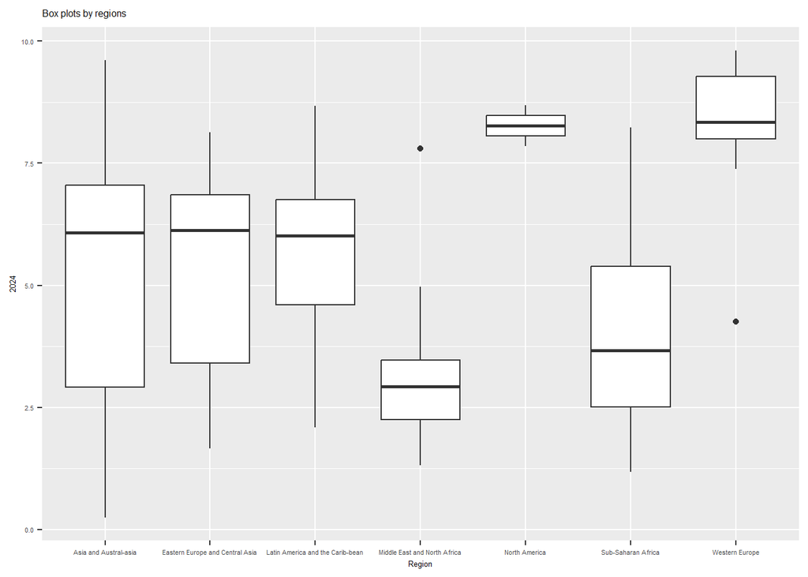

```r
p2 <- ggplot(countries)
p2 <- p2 + geom_boxplot(aes(x=Region, y=X2024)) +theme(text = element_text(size = 5)) + labs(y = "2024",title = "Box plots by regions")
p2
```

Now let’s have a look on some unique countries, in terms of Democracy Index, In our close neighborhood:

```r
p3 <- countries %>% select(Country,Region,X2024) %>% filter(Region == "Middle East and North Africa")
p4 <- countries %>% select(Country,Region,X2024) %>% filter(Region == "Western Europe")
out_3 <- boxplot.stats(p3$X2024)$out
out_ind_3 <- which(p3$X2024 %in% c(out_3))
out_4 <- boxplot.stats(p4$X2024)$out
out_ind_4 <- which(p4$X2024 %in% c(out_4))
print("Outliers Countries In Westren Europe and the Middle East:")
```

```
## [1] "Outliers Countries In Westren Europe and the Middle East:"
```

```r
rbind(p3[out_ind_3,],p4[out_ind_4,]) %>% mutate(Rate_of_2024 = X2024) %>% select(-c(X2024))
```

```
##    Country                       Region Rate_of_2024
## 6   Israel Middle East and North Africa         7.80
## 20  Turkey               Western Europe         4.26
```

We can see that Israel is the uniquely country in terms of high Democracy Rate in the middle east, and Turkey is uniquely low in Democracy Rate in Western Europe. Pretty much as expected.

## (b) Regions density plots

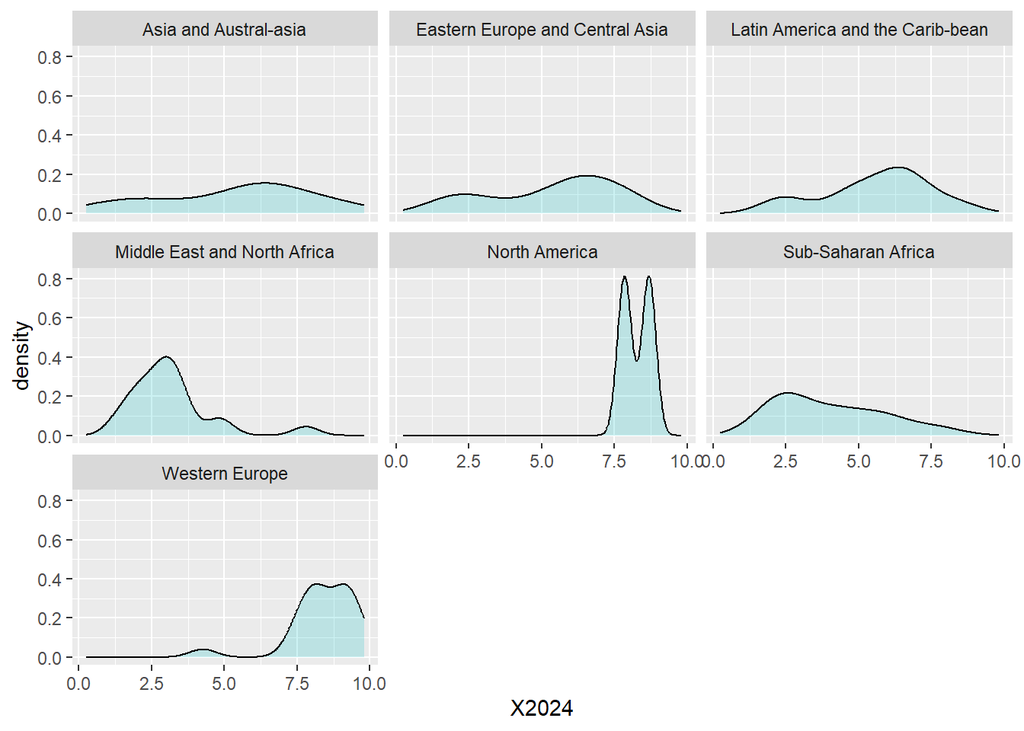

```r
p5 <- ggplot(countries,aes(X2024)) + geom_density(alpha=.2, fill= "#00BFC4") + facet_wrap(~Region)
p5
```

```r
p6 <- countries %>%
     group_by(Region) %>%
     summarize(Mean = round(mean(X2024),2),
               Variance = round(var(X2024),2),
               Skewness = round(skewness(X2024),2),
               Kurtosis = round(kurtosis(X2024),2))
p6
```

```
## # A tibble: 7 × 5
##   Region                           Mean Variance Skewness Kurtosis
##   <chr>                           <dbl>    <dbl>    <dbl>    <dbl>
## 1 Asia and Australasia             5.31     6.76    -0.38     2.15
## 2 Eastern Europe and Central Asia  5.35     4.55    -0.51     1.91
## 3 Latin America and the Caribbean  5.61     3.35    -0.49     2.49
## 4 Middle East and North Africa     3.12     2.08     1.74     6.63
## 5 North America                    8.27     0.35     0        1
## 6 Sub-Saharan Africa               4        3.41     0.57     2.29
## 7 Western Europe                   8.38     1.39    -1.99     8.12
```